# Biométrie humaine

Analyse concernant l’impact de l’âge sur la masse des humains

Delgrange Lucien

Etudiant à l’université de Mons en BAC2 Biologie

11 décembre 2017

# 1 Introduction

La mesure des caractéristiques physiques d’un individu humain n’est pas sans intérêts. En effet, l’insuffisance pondérale et l’obésité peuvent induire de nombreuses pathologies. L’élément le plus pertinent pour déceler ces situations risquées est le taux de masse grasse. Les techniques permettant d’estimer celui-ci ( pesée hydrostatique , Impédancemétrie) sont cependant peu accessibles (couteuses) et souvent approximatives. C’est pourquoi de nombreuses formules ont été mises en place pour mesurer la corpulence d’un individu tout en évitant les contraintes liées à la mesure du taux de masse grasse. Pour son côté pratique, l’IMC : indice de masse corporelle est la technique la plus utilisée. En effêt, il repose uniquement sur la taille et la masse de l’individu. Il comporte cependant des biais : comme par exemple, la non prise en compte de la masse musculaire.

De nombreux facteurs peuvent favoriser les problèmes de corpulence. Certains sont contrôlables, comme par exemple l’alimentation et les dépenses physiques. Mais il en existe également d’autres comme les facteurs génétiques et hormonaux.

# 2 But

L’objet de cette analyse est de savoir si l’âge est un des facteurs influençant la masse des humains et si ce facteur est plus marqué ou non chez un des deux sexes.

```r
library(readxl)
biometrie_3 <- read_excel("../data/biometrie_10.xlsx",
    skip = 26)
library(readxl)
biometrie_4 <- read_excel("../data/biometrie_10.xlsx",
    skip = 26)
```

# 3 Matériels et méthodes

## 3.1 Acquisition des données

Les données biométriques ont été recueillies par les étudiants de BAC2 en sciences biologiques à l’université de Mons (Belgique). Chaque étudiant a réalisé une série de mesures qualitative et quantitatives sur 5 personnes ayant de 18 à 65 ans. Les femmes enceintes n’ont pas été mesurées.

## 3.2 Analyse des données

Nous fixons le seuil alpha à 0.05 pour l’ensemble des analyses ci dessous

1. Pour comparer les masses selon l’âge et l’augmentation de masse liée à l’âge en fonction du sexe , nous utilisons le test d’hypothèse : test-t de Student comparant deux groupes d’échantillons indépendants.

Les hypothèses sont :

$H_{0}$ : $\mu_{1} = \mu_{2}$

$H_{1}$ : $\mu_{1} \ne \mu_{2}$

Les conditions de validités du test sont :

- Un échantillonnage aléatoire
- Des observations indépendantes les unes des autres

Ces deux conditions sont supposées validées

- Une distribution des résidus qui doit suivre une distribution normale ou approximativement normale : un graphique quantile-quantile de comparaison de la distribution des résidus avec une distribution normale permet d’observer si cette condition est respectée.

Et/ou un grand nombre d’observations

Cette dernière condition sera testée lors de l’analyse statistique.

# 4 Résultats

```r
library("readxl")
library("dplyr")
all_data <- dir("../data", full.names = TRUE)
# Premier fichier
biom <- read_excel(all_data[1], skip = 25)
# ConcatÃ¨ne tous les autres
for (f in all_data[-1]) {
  #print(f)
  biom <- bind_rows(biom, read_excel(f, skip = 25))
}
```

```r
## Recoding biom$activite
biom$activite[biom$activite == "sédentaire"] <- "sedentaire"
biom$activite[biom$activite == "active"] <- "actif"
biom$activite <- factor(biom$activite)
## Recoding biom$type_ant
biom$type_ant[biom$type_ant == "caucasoïde"] <- "caucasoide"
biom$type_ant[biom$type_ant == "caucasien"] <- "caucasoide"
biom$type_ant <- factor(biom$type_ant, levels = c ("australoide","mongoloide","caucasoide","negroide"))
```

```r
biom %>% filter(age >= 18) -> biom18
```

```r
biom18 %>% filter (biom18$sexe=="f") -> biomf
biom18 %>% filter (biom18$sexe=="m") -> biomm
```

## 4.1 Masse des personnes mesurées

### 4.1.1 Statistiques descriptives

#### 4.1.1.1 Statistiques descriptives numériques

Le jeu de donnée est découpé en 2 catégories d’âges : - Les personnes agées de 18 à 33 ans - Les personnes agées de 34 à 65 ans

```r
library(tidyverse)
biom18$age_categorie <- cut(biom18$age, include.lowest=TRUE,  right=TRUE,
                          breaks=c(18, 33, 65))
## Recodage de biom18$age_categorie
biom18$age_categorie <- as.character(biom18$age_categorie)
biom18$age_categorie <- factor(biom18$age_categorie)
## Réordonnancement de biom18$age_categorie
biom18$age_categorie <- factor(biom18$age_categorie, levels=c("[18,33]", "(33,65]"))
## Recodage de biom18$age_categorie
biom18$age_categorie <- fct_recode(biom18$age_categorie,
               "18 à 33 ans" = "[18,33]",
               "34 à 65 ans" = "(33,65]")
biom18$sexe <- as.character(biom18$sexe)
biom18$sexe <- factor(biom18$sexe)
```

```r
library(dplyr)
biom18%>%group_by(age_categorie)%>% summarise("mean" = mean(masse, na.rm=TRUE), "sd" = sd(masse, na.rm=TRUE), "number" = length(masse)) -> masse_age
library(knitr)
kable(x = masse_age, format = "pandoc", caption = "Tableau de la masse moyenne des personnes mesurées selon leur catégorie d'âge. ", col.names = c("Catégorie d'âge", "Masse moyenne", "Ecart-type", "Nombre d'observations"), align = "c")
```

Tableau de la masse moyenne des personnes mesurées selon leur catégorie d'âge.

| Catégorie d'âge | Masse moyenne | Ecart-type | Nombre d'observations |
| --- | --- | --- | --- |
| 18 à 33 ans | 66.15823 | 13.07339 | 79 |
| 34 à 65 ans | 73.52295 | 16.50527 | 61 |

La moyenne de la masses des personnes mesurées est différente pour les personnes agées 18 à 33 ans ($66.15823 \pm13.07339 kg$) et pour les personnes agées de 34 à 65 ans ($73.52295\pm16.50527 kg$).

#### 4.1.1.2 Statistiques descriptives graphiques

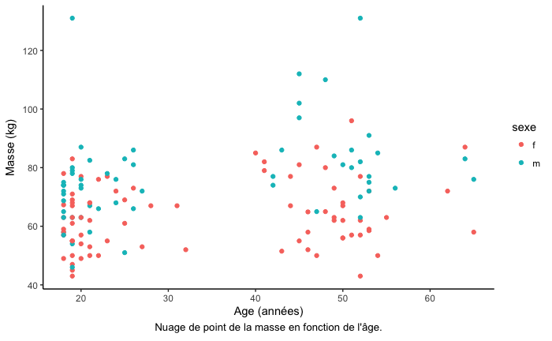

```r
library(ggplot2)
ggplot(data = biom18, mapping = aes(x = age, y = masse)) +
  geom_point( mapping = aes(color = sexe))+
  theme_classic() +
 labs( x = "Age (années)", y = "Masse (kg)", caption = expression(paste("Nuage de point de la masse en fonction de l'âge.")))+
  theme(plot.caption = element_text(hjust = 0.5, size = 10))
```

Ce graphique nous donne l’information que la population mesurée est répartie en 2 catégories d’âges visibles.

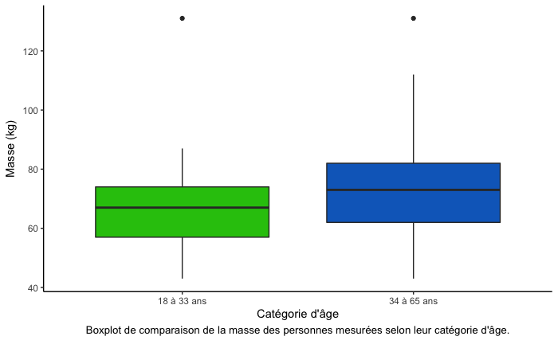

```r
library("ggplot2")
ggplot(data=biom18) +
  geom_boxplot(mapping=aes(x= as.factor(age_categorie),y=masse), fill=c("#26c40d", "#0d6bc4"))+
theme_classic() +
 labs( x = "Catégorie d'âge", y = "Masse (kg)", caption = expression(paste("Boxplot de comparaison de la masse des personnes mesurées selon leur catégorie d'âge.")))+
  theme(plot.caption = element_text(hjust = 0.5, size = 10))
```

La représentation graphique sous forme de boxplot permet de se représenter visuellement sur les 5 nombres : la valeur minimale, le premier quartile, la mediane, le troisième quartile et la valeur maximale. Le graphique semble nous faire part d’une différence entre la masse des personnes agées de 18 à 33 ans et la masse des personnes agées de 34 à 65 ans

### 4.1.2 Statistiques

#### 4.1.2.1 Test d’hypothèse

```r
library(dplyr)
biom18 %>% mutate(masse.res = masse - ave(masse, age_categorie)) -> biom18
```

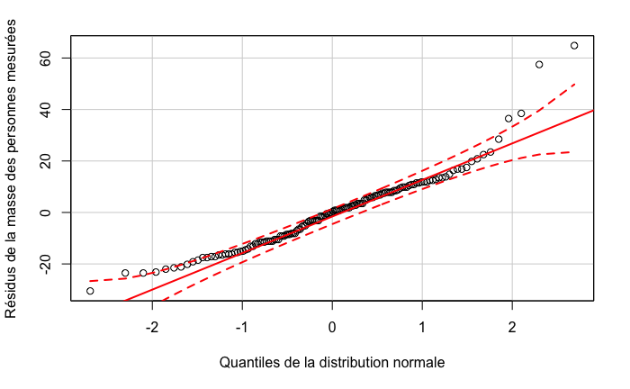

```r
car::qqPlot(biom18$masse.res, distribution = "norm",
  envelope = 0.95, col = "Black", ylab = "Résidus de la masse des personnes mesurées",xlab = "Quantiles de la distribution normale")
```

- 6 points sur ne suivent pas la distribution normale à une intervalle de confiance de 95%. Pour pallier à ce problème, les données peuvent être transformées.

-Le nombre d’observation est élevé, test-t de student comparant deux groupes d’échantillons indépendants peut tout de même être appliqué

Afin d’obtenir un meilleur résultat, la transformation des données a été décidée.

## 4.2 Logarithme des Masses des personnes mesurées

```r
library(dplyr)
biom18%>% mutate(log_masse = log(masse)) -> biom18
```

### 4.2.1 Statistiques descriptives

#### 4.2.1.1 Statistiques descriptives numériques

```r
library(dplyr)
biom18%>%group_by(age_categorie)%>% summarise("mean" = mean(log_masse, na.rm=TRUE), "sd" = sd(log_masse, na.rm=TRUE), "number" = length(log_masse)) -> log_masse_age
library(knitr)
kable(x = log_masse_age, format = "pandoc", caption = "Tableau du logarithme des masse moyenne des personnes mesurées selon leur catégorie d'âge. ", col.names = c("Catégorie d'âge", "Logarithme des moyennes des masses", "Ecart-type", "Nombre d'observations"), align = "c")
```

Tableau du logarithme des masse moyenne des personnes mesurées selon leur catégorie d'âge.

| Catégorie d'âge | Logarithme des moyennes des masses | Ecart-type | Nombre d'observations |
| --- | --- | --- | --- |
| 18 à 33 ans | 4.174208 | 0.1881631 | 79 |
| 34 à 65 ans | 4.274070 | 0.2172244 | 61 |

Le logarithme des moyennes des masses des personnes mesurées est différente pour les personnes agées 18 à 33 ans ($4.174208 \pm0.1881631$) et pour les personnes agées de 34 à 65 ans ($4.2740700.2172244 $).

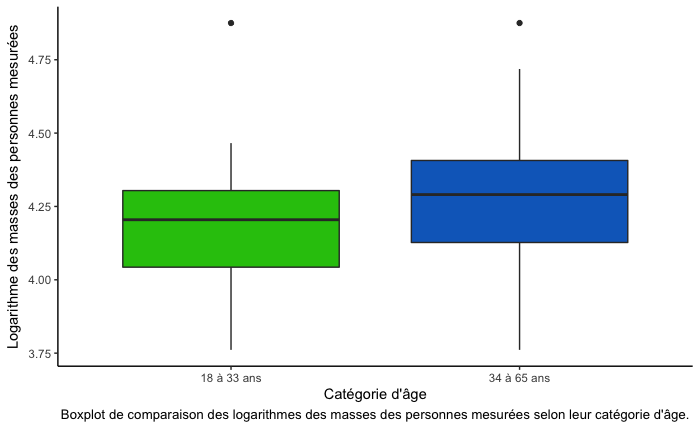

```r
library("ggplot2")
ggplot(data=biom18) +
  geom_boxplot(mapping=aes(x= as.factor(age_categorie),y=log_masse), fill=c("#26c40d", "#0d6bc4"))+
theme_classic() +
 labs( x = "Catégorie d'âge", y = "Logarithme des masses des personnes mesurées", caption = expression(paste("Boxplot de comparaison des logarithmes des masses des personnes mesurées selon leur catégorie d'âge.")))+
  theme(plot.caption = element_text(hjust = 0.5, size = 10))
```

La représentation graphique sous forme de boxplot permet de se représenter visuellement sur les 5 nombres : la valeur minimale, le premier quartile, la mediane, le troisième quartile et la valeur maximale. Le graphique semble nous faire part d’une différence entre le logarithme des masses des personnes agées de 18 à 33 ans et la masse des personnes agées de 34 à 65 ans

```r
biom18 %>% filter (biom18$sexe=="f") -> biomf
biom18 %>% filter (biom18$sexe=="m") -> biomm
```

```r
biom18$categorie_age_sexe <- with(biom18, interaction(age_categorie,  sexe), drop = TRUE )
## Recodage de biom18$categorie_age_sexe
biom18$categorie_age_sexe <- fct_recode(biom18$categorie_age_sexe,
               "Femmes de 18 à 33 ans" = "18 à 33 ans.f",
               "Femmes de 34 à 65 ans" = "34 à 65 ans.f",
               "Hommes de 18 à 33 ans" = "18 à 33 ans.m",
               "Hommes de 34 à 65 ans" = "34 à 65 ans.m")
```

```r
library(dplyr)
biom18%>%group_by(categorie_age_sexe)%>% summarise("mean" = mean(log_masse, na.rm=TRUE), "sd" = sd(log_masse, na.rm=TRUE), "number" = length(log_masse)) -> log_masse_age_sexe
library(knitr)
kable(x = log_masse_age_sexe, format = "pandoc", caption = "Tableau du logarithme des masse moyenne des personnes mesurées selon leur catégorie d'âge et leur sexe. ", col.names = c("Catégorie d'âge et sexe", "Logarithme des moyennes des masses", "Ecart-type", "Nombre d'observations"), align = "c")
```

Tableau du logarithme des masse moyenne des personnes mesurées selon leur catégorie d'âge et leur sexe.

| Catégorie d'âge et sexe | Logarithme des moyennes des masses | Ecart-type | Nombre d'observations |
| --- | --- | --- | --- |
| Femmes de 18 à 33 ans | 4.102882 | 0.1640548 | 43 |
| Femmes de 34 à 65 ans | 4.177198 | 0.1861352 | 37 |
| Hommes de 18 à 33 ans | 4.259404 | 0.1813572 | 36 |
| Hommes de 34 à 65 ans | 4.423415 | 0.1746314 | 24 |

- Le logarithme des moyennes des masses des est différent entre lesfemmes agées 18 à 33 ans ($4.102882 \pm0.1640548$) et les femmes agées de 34 à 65 ans ($4.177198\pm0.1861352$).
- Il est également différent entre les hommes de 18 à 33 ans ($4.259404\pm0.1813572$) et les hommes de 34 à 65 ans ($4.423415\pm0.1746314$)

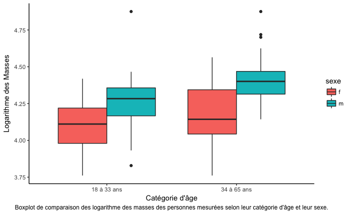

```r
library(ggplot2)
ggplot(data=biom18) +
  geom_boxplot(mapping=aes(x= as.factor(age_categorie),y=log_masse, fill=sexe))+
  theme_classic() +
 labs( x = "Catégorie d'âge", y = "Logarithme des Masses", caption = expression(paste("Boxplot de comparaison des logarithme des masses des personnes mesurées selon leur catégorie d'âge et leur sexe.")))+
  theme(plot.caption = element_text(hjust = 0.5, size = 9))
```

Le graphique semble nous montrer une différence entre le logarithme des masses des femmes agées de 18 à 33 ans et des femmes agées de 34 à 65 ans.

Il semble également nous montrer une différence entre le logarithme des masses des hommes agés de 18 à 33 ans et des hommes agés de 34 à 65 ans.

### 4.2.2 Statistiques

#### 4.2.2.1 Tests d’hypothèse

##### 4.2.2.1.1 Moyennes des logarithmes des masses

```r
library(dplyr)
biom18%>% mutate(log_masse= log (masse)) -> biom18
library(dplyr)
biom18 %>% mutate(log_masse.res = log_masse - ave( log_masse, age_categorie)) -> biom18
```

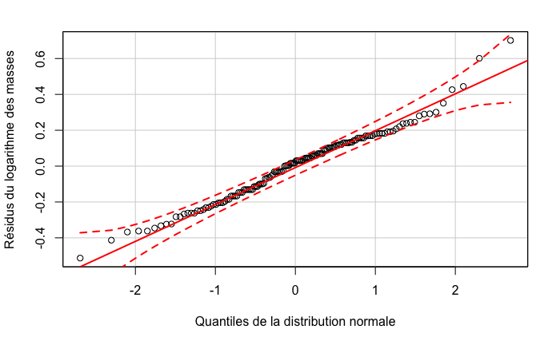

```r
car::qqPlot(biom18$log_masse.res, distribution = "norm",
  envelope = 0.95, col = "Black", ylab = "Résidus du logarithme des masses",xlab = "Quantiles de la distribution normale")
```

Tous les points suivent une distribution normale.

- La distribution des résidus du logarithme des masses suit une distribution normale ( avec une intervale de confiance de 95%). Le premier critère d’application du test-t de student comparant deux groupes d’échantillons indépendants est donc respecté.
- Le nombre d’obeservations est élevé.

-> Le test-t de student indépendant peut être appliqué.

Les hypothèses sont :

$H_{0}$ : $\mu_{18-33} = \mu_{34-65}$

##### 4.2.2.1.2 Moyennes des logarithmes des masses des hommes

```r
library(dplyr)
biomm %>% mutate(log_masse= log (masse)) -> biomm
```

```r
library(dplyr)
biomm %>% mutate(log_masse.res = log_masse - ave( log_masse, age_categorie)) -> biomm
```

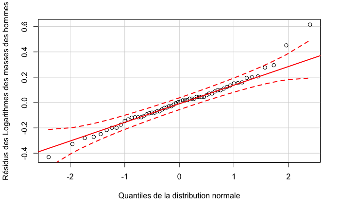

```r
car::qqPlot(biomm$log_masse.res, distribution = "norm",
  envelope = 0.95, col = "Black", ylab = "Résidus des Logarithmes des masses des hommes",xlab = "Quantiles de la distribution normale")
```

Seulement 2 points ne suivent une distribution normale.

- La distribution des résidus du logarithme de la masse des homme suit à à peu près une distribution normale ( avec une intervale de confiance de 95%). Le premier critère d’application du test-t de student comparant deux groupes d’échantillons indépendants est respecté.
- Le nombre d’obeservations est élevé.

-> Le test-t de student indépendant peut être appliqué.

Les hypothèses sont :

$H_{0}$ : $\mu_{♂18-33} = \mu_{♂34-65}$

$H_{1}$ : $\mu_{♂18-33} \ne \mu_{♂34-65}$

```r
t.test(log_masse ~ age_categorie, data = biomm,
  alternative = "two.sided", conf.level = 0.95, var.equal = TRUE)
```

```
    Two Sample t-test

data:  log_masse by age_categorie
t = -3.4824, df = 58, p-value = 0.0009517
alternative hypothesis: true difference in means is not equal to 0
95 percent confidence interval:
 -0.25828532 -0.06973574
sample estimates:
mean in group 18 à 33 ans mean in group 34 à 65 ans
                 4.259404                  4.423415
```

Le degré de confiance est fixé au seuil $\alpha$ de 0.05 Le seuil de probabilité critique ( p ) est égale à 0.0009517 p < 0.05

->On a une différence significative entre les moyennes au seuil $\alpha$ de 0.05 -> L’hypothèse $H_{0}$ : $\mu_{♂18-33} = \mu_{♂34-65}$ est rejetée

##### 4.2.2.1.3 Moyennes des logarithmes des masses des femmes

```r
library(dplyr)
biomf %>% mutate(log_masse= log (masse)) -> biomf
```

```r
biomf %>% mutate(log_masse.res= log_masse - ave( log_masse, age_categorie)) -> biomf
```

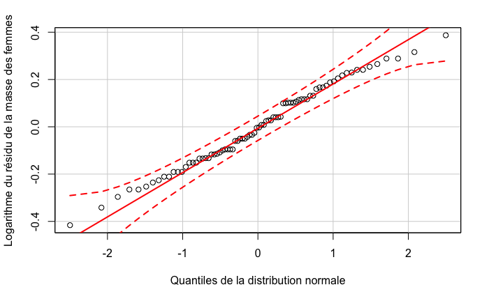

```r
car::qqPlot(biomf$log_masse.res, distribution = "norm",
  envelope = 0.95, col = "Black", ylab = "Logarithme du résidu de la masse des femmes",xlab = "Quantiles de la distribution normale")
```

Tous les points suivent une distribution normale.

-> Le test-t de student indépendant peut être appliqué.

$H_{0}$ : $\mu_{♀18-33} = \mu_{♀34-65}$

$H_{1}$ : $\mu_{♀18-33} \ne \mu_{♀34-65}$

```r
t.test(log_masse ~ age_categorie, data = biomf,
  alternative = "two.sided", conf.level = 0.95, var.equal = TRUE)
```

```
    Two Sample t-test

data:  log_masse by age_categorie
t = -1.8982, df = 78, p-value = 0.06137
alternative hypothesis: true difference in means is not equal to 0
95 percent confidence interval:
 -0.152258957  0.003626248
sample estimates:
mean in group 18 à 33 ans mean in group 34 à 65 ans
                 4.102882                  4.177198
```

->On n’a pas de différence significative entre les moyennes au seuil $\alpha$ de 0.05 -> L’hypothèse $H_{1}$ : $\mu_{♀18-33} \ne \mu_{♀34-65}$ est rejetée

# 5 Discussion

Le logarithme des masses des hommes agés de 34 à 65 ans, avec comme valeur moyenne (4.423415±0.1746314) ,est significativement différent du logarithme des masses des hommes agés de 18 à 33 ans (avec comme valeur moyenne 4.259404±0.1813572).

Le logarithme des masses des femmes agées de 34 à 65 ans, avec comme valeur moyenne (4.177198±0.1861352) n’est pas significativement différent du logarithme des masses des femmes agées de 18 à 33 ans ( avec comme valeur moyenne 4.102882±0.1640548).

La limite de cette analyse réside dans le fait que la plus part des échantillons ont été mesuré dans l’entourage ( familles, amis) de la personne ayant effectué les mesures. Ainsi, des facteurs génétiques et culturels communs ne rendent pas compte de la réelle diversité biométrique. Les deux catégories d’âges apparues dans le graphique nuage de points de la masse en fonction de l’âge mettent clairement en évidence la présence de deux générations distinctes : les étudiants et leur frères et soeurs dans la catégorie des 18-13 ans et les parents et grands parents dans la catégorie des 34 - 65 ans.

# 6 Conclusion

# 7 Bibliographies

- T. de Saint Pol, 2007, « Comment mesurer la corpulence et le poids “idéal” ? Histoire, intérêts et limites de l’Indice de masse corporelle », Notes & Documents, 200701, Paris, Sciences Po/CNRS.